# titanic-data-visualization-and-ml

```python
# This Python 3 environment comes with many helpful analytics libraries installed
# It is defined by the kaggle/python docker image: https://github.com/kaggle/docker-python
# For example, here's several helpful packages to load in

import numpy as np # linear algebra
import pandas as pd # data processing, CSV file I/O (e.g. pd.read_csv)

# Input data files are available in the "../input/" directory.
# For example, running this (by clicking run or pressing Shift+Enter) will list the files in the input directory

from subprocess import check_output
print(check_output(["ls", "../input"]).decode("utf8"))

# Any results you write to the current directory are saved as output.
```

```
gender_submission.csv
test.csv
train.csv
```

```python
from pandas import Series,DataFrame
import matplotlib.pyplot as plt
import seaborn as sns
from sklearn.linear_model import LogisticRegression
from sklearn import metrics
from sklearn.cross_validation import train_test_split
from sklearn.ensemble import RandomForestClassifier
sns.set_style('whitegrid')

%matplotlib inline
```

```python
###Loading the data
titanic_df = pd.read_csv('../input/train.csv')
titanic_df.head()
```

|  | PassengerId | Survived | Pclass | Name | Sex | Age | SibSp | Parch | Ticket | Fare | Cabin | Embarked |
| --- | --- | --- | --- | --- | --- | --- | --- | --- | --- | --- | --- | --- |
| 0 | 1 | 0 | 3 | Braund, Mr. Owen Harris | male | 22.0 | 1 | 0 | A/5 21171 | 7.2500 | NaN | S |
| 1 | 2 | 1 | 1 | Cumings, Mrs. John Bradley (Florence Briggs Th... | female | 38.0 | 1 | 0 | PC 17599 | 71.2833 | C85 | C |
| 2 | 3 | 1 | 3 | Heikkinen, Miss. Laina | female | 26.0 | 0 | 0 | STON/O2. 3101282 | 7.9250 | NaN | S |
| 3 | 4 | 1 | 1 | Futrelle, Mrs. Jacques Heath (Lily May Peel) | female | 35.0 | 1 | 0 | 113803 | 53.1000 | C123 | S |
| 4 | 5 | 0 | 3 | Allen, Mr. William Henry | male | 35.0 | 0 | 0 | 373450 | 8.0500 | NaN | S |

```python
titanic_df.info()
```

```
<class 'pandas.core.frame.DataFrame'>
RangeIndex: 891 entries, 0 to 890
Data columns (total 12 columns):
PassengerId    891 non-null int64
Survived       891 non-null int64
Pclass         891 non-null int64
Name           891 non-null object
Sex            891 non-null object
Age            714 non-null float64
SibSp          891 non-null int64
Parch          891 non-null int64
Ticket         891 non-null object
Fare           891 non-null float64
Cabin          204 non-null object
Embarked       889 non-null object
dtypes: float64(2), int64(5), object(5)
memory usage: 83.6+ KB
```

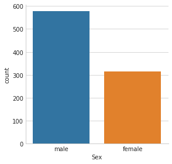

```python
###Who were the passengers on the titanic? (What age, gender, class etc)

###Gender Plot
sns.factorplot('Sex',data=titanic_df,kind='count')

### Shows more male passengers than female
```

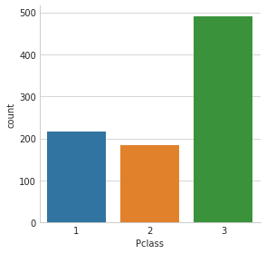

```python
### Class plot
sns.factorplot('Pclass',data=titanic_df,kind='count')
```

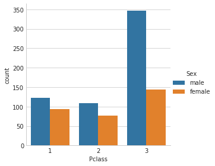

```python
###Interesting! More passengers are from class Three. Now lets find the gender ration among the classes

sns.factorplot('Pclass',data=titanic_df,hue='Sex',kind='count')
```

```python
##This gives us an insight that there are quite a few males than females in 3rd class. Now lets dig deeper and find the children among the passengers.

def titanic_children(passenger):

    age , sex = passenger
    if age <16:
        return 'child'
    else:
        return sex

titanic_df['person'] = titanic_df[['Age','Sex']].apply(titanic_children,axis=1)
```

```python
titanic_df.head(10)
```

|  | PassengerId | Survived | Pclass | Name | Sex | Age | SibSp | Parch | Ticket | Fare | Cabin | Embarked | person |
| --- | --- | --- | --- | --- | --- | --- | --- | --- | --- | --- | --- | --- | --- |
| 0 | 1 | 0 | 3 | Braund, Mr. Owen Harris | male | 22.0 | 1 | 0 | A/5 21171 | 7.2500 | NaN | S | male |
| 1 | 2 | 1 | 1 | Cumings, Mrs. John Bradley (Florence Briggs Th... | female | 38.0 | 1 | 0 | PC 17599 | 71.2833 | C85 | C | female |
| 2 | 3 | 1 | 3 | Heikkinen, Miss. Laina | female | 26.0 | 0 | 0 | STON/O2. 3101282 | 7.9250 | NaN | S | female |
| 3 | 4 | 1 | 1 | Futrelle, Mrs. Jacques Heath (Lily May Peel) | female | 35.0 | 1 | 0 | 113803 | 53.1000 | C123 | S | female |
| 4 | 5 | 0 | 3 | Allen, Mr. William Henry | male | 35.0 | 0 | 0 | 373450 | 8.0500 | NaN | S | male |
| 5 | 6 | 0 | 3 | Moran, Mr. James | male | NaN | 0 | 0 | 330877 | 8.4583 | NaN | Q | male |
| 6 | 7 | 0 | 1 | McCarthy, Mr. Timothy J | male | 54.0 | 0 | 0 | 17463 | 51.8625 | E46 | S | male |
| 7 | 8 | 0 | 3 | Palsson, Master. Gosta Leonard | male | 2.0 | 3 | 1 | 349909 | 21.0750 | NaN | S | child |
| 8 | 9 | 1 | 3 | Johnson, Mrs. Oscar W (Elisabeth Vilhelmina Berg) | female | 27.0 | 0 | 2 | 347742 | 11.1333 | NaN | S | female |
| 9 | 10 | 1 | 2 | Nasser, Mrs. Nicholas (Adele Achem) | female | 14.0 | 1 | 0 | 237736 | 30.0708 | NaN | C | child |

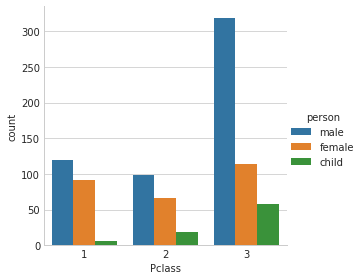

```python
### Plotting a graph to check the ratio of male,female and children in each category of class

sns.factorplot('Pclass',data=titanic_df,hue='person',kind='count')
```

More number of males, females and children in the class three. WIll this insight help us in making prediction? let's check it out!

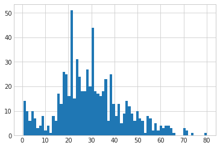

```python
###Now let us look at the ages of the passengers

titanic_df['Age'].hist(bins=70)
```

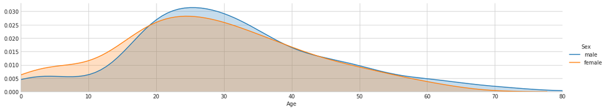

```python
as_fig = sns.FacetGrid(titanic_df,hue='Sex',aspect=5)

as_fig.map(sns.kdeplot,'Age',shade=True)

oldest = titanic_df['Age'].max()

as_fig.set(xlim=(0,oldest))

as_fig.add_legend()
```

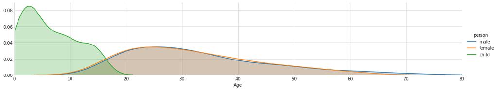

```python
as_fig = sns.FacetGrid(titanic_df,hue='person',aspect=5)

as_fig.map(sns.kdeplot,'Age',shade=True)

oldest = titanic_df['Age'].max()

as_fig.set(xlim=(0,oldest))

as_fig.add_legend()
```

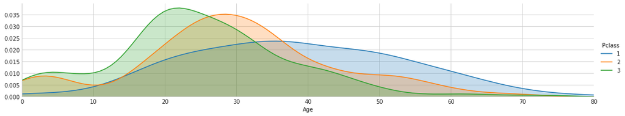

```python
as_fig = sns.FacetGrid(titanic_df,hue='Pclass',aspect=5)

as_fig.map(sns.kdeplot,'Age',shade=True)

oldest = titanic_df['Age'].max()

as_fig.set(xlim=(0,oldest))

as_fig.add_legend()
```

From the above graphs, we can infer that there are more number of passengers with a age group of 20 to 40 in all the three classes.

```python
###Mean age of the passengers
titanic_df['Age'].mean()
```

```
29.69911764705882
```

```python
titanic_df['Age'] = titanic_df['Age'].fillna(titanic_df['Age'].mean())
```

```python
#### Drop the Cabin column as there are many null values and it does not help in making prediction

titanic_df.drop('Cabin',axis=1,inplace=True)
```

```python
## Filling the null values in the Embarked column with S as there are more number of passengers boarded from Southhampton
titanic_df['Embarked'] = titanic_df['Embarked'].fillna('S')
```

```python
## To check if there are still any null values in the dataset
titanic_df.isnull().values.any()
```

```
False
```

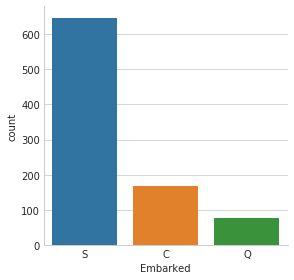

```python
sns.factorplot('Embarked',data=titanic_df,kind='count')
```

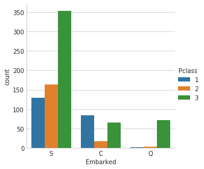

```python
sns.factorplot('Embarked',data=titanic_df,hue='Pclass',kind='count')
```

It is intereting to see that most of the passengers boarded at Queenstown are from 3rd class. And many passengers boarded at Southhampton. Will this help in making predictions?

```python
## Let's check who are with family and who are alone
## This can be found by adding Parch and Sibsp columns
titanic_df['Alone'] = titanic_df.Parch + titanic_df.SibSp
```

```python
## if Alone value is >0 then they are with family else they are Alone

titanic_df['Alone'].loc[titanic_df['Alone']>0] = 'With Family'
titanic_df['Alone'].loc[titanic_df['Alone'] == 0] = 'Without Family'
```

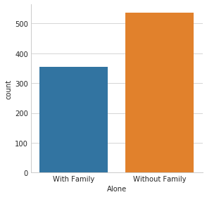

```python
#Let us visualise the Alone column

sns.factorplot('Alone',kind='count',data=titanic_df)
```

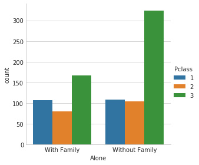

```python
# let us see who are alone according to class
sns.factorplot('Alone',kind='count',data=titanic_df,hue='Pclass')
```

Let's dig deeper into data and find out what factors helped survival.

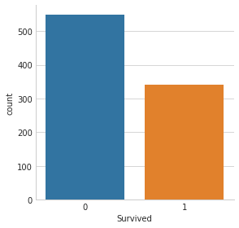

```python
sns.factorplot('Survived',data=titanic_df,kind='count')
```

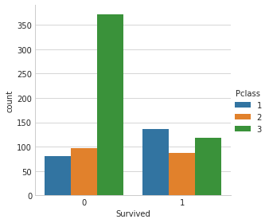

```python
## checking of the class had any effect in the survival rate
sns.factorplot('Survived',data=titanic_df,kind='count',hue='Pclass')
```

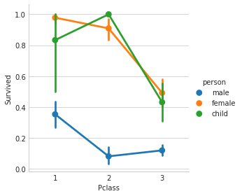

```python
sns.factorplot('Pclass','Survived',data=titanic_df,hue='person')
```

The above graph shows that the survival rate for male is very low nevertheless of the class. And, the survival rate is less for the 3rd class passengers.

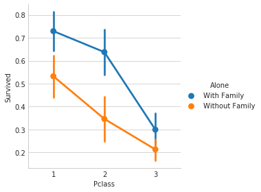

```python
sns.factorplot('Pclass','Survived',data=titanic_df,hue='Alone')
```

As expected, the survival rates are higher if they are with family. Let us check how Age playes a role in the survival rate.

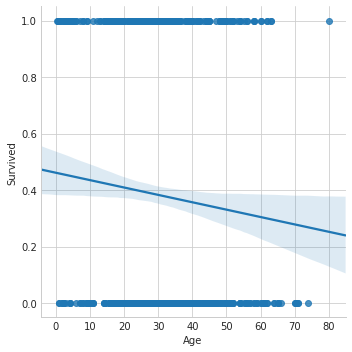

```python
sns.lmplot('Age','Survived',data=titanic_df)
```

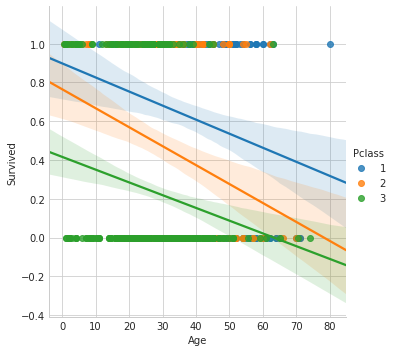

```python
sns.lmplot('Age','Survived',data=titanic_df,hue='Pclass')
```

The above graphs shows that older the passenger, lesser the chance of survival.

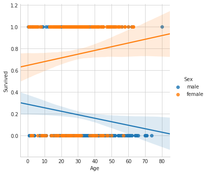

```python
sns.lmplot('Age','Survived',data=titanic_df,hue='Sex')
```

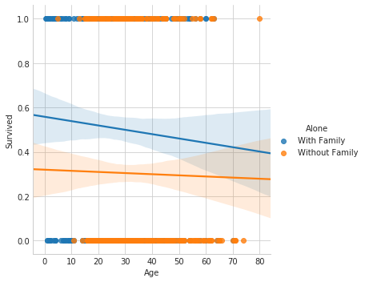

```python
sns.lmplot('Age','Survived',data=titanic_df,hue='Alone')
```

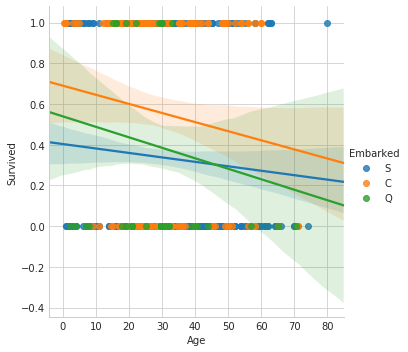

```python
sns.lmplot('Age','Survived',data=titanic_df,hue='Embarked')
```

Shockingly, the number of passengers boarded at Southhampton are more compared to Cherbourg and Queenstown but the survival rate is high for Cherbour passengers than Southhampton. So there is a chance that Embarked helps in prediction. Let us create dummies of the Embarked and drop the Queenstown to avoid multicollinearity(might be caused due to dummies) and there are quiet a few passengers boarded at Queenstown(more are from 3rd class which has less survival rate)

```python
person_dummies = pd.get_dummies(titanic_df['person'])
alone_dummies = pd.get_dummies(titanic_df['Alone'])

embarked_dummies = pd.get_dummies(titanic_df['Embarked'])

embarked_dummies.drop('Q',axis=1,inplace=True)
```

```python
pclass_dummies = pd.get_dummies(titanic_df['Pclass'])

pclass_dummies.columns=['class_1','class_2','class_3']
```

```python
import math

titanic_df['Age'] = titanic_df['Age'].apply(math.ceil)
titanic_df['Fare'] = titanic_df['Fare'].apply(math.ceil)
```

```python
titanic_df = pd.concat([titanic_df,pclass_dummies,person_dummies,alone_dummies,embarked_dummies],axis=1)
```

```python
titanic_df.drop(['PassengerId','Name','Sex','SibSp','Parch','Ticket','Embarked'],axis=1,inplace=True)
titanic_df.drop(['Alone','person','Pclass','Without Family','male','class_3'],axis=1,inplace=True)
```

```python
titanic_df.head()
```

|  | Survived | Age | Fare | class_1 | class_2 | child | female | With Family | C | S |
| --- | --- | --- | --- | --- | --- | --- | --- | --- | --- | --- |
| 0 | 0 | 22 | 8 | 0 | 0 | 0 | 0 | 1 | 0 | 1 |
| 1 | 1 | 38 | 72 | 1 | 0 | 0 | 1 | 1 | 1 | 0 |
| 2 | 1 | 26 | 8 | 0 | 0 | 0 | 1 | 0 | 0 | 1 |
| 3 | 1 | 35 | 54 | 1 | 0 | 0 | 1 | 1 | 0 | 1 |
| 4 | 0 | 35 | 9 | 0 | 0 | 0 | 0 | 0 | 0 | 1 |

```python
titanic_train = titanic_df.drop('Survived',axis=1)
titanic_survived = titanic_df.Survived
```

```python
x_train, x_test, y_train, y_test = train_test_split(titanic_train,titanic_survived,test_size=0.2)
```

```python
x_train.head()
```

|  | Age | Fare | class_1 | class_2 | child | female | With Family | C | S |
| --- | --- | --- | --- | --- | --- | --- | --- | --- | --- |
| 96 | 71 | 35 | 1 | 0 | 0 | 0 | 0 | 1 | 0 |
| 705 | 39 | 26 | 0 | 1 | 0 | 0 | 0 | 0 | 1 |
| 640 | 20 | 8 | 0 | 0 | 0 | 0 | 0 | 0 | 1 |
| 300 | 30 | 8 | 0 | 0 | 0 | 1 | 0 | 0 | 0 |
| 451 | 30 | 20 | 0 | 0 | 0 | 0 | 1 | 0 | 1 |

```python
x_train.head()
```

|  | Age | Fare | class_1 | class_2 | child | female | With Family | C | S |
| --- | --- | --- | --- | --- | --- | --- | --- | --- | --- |
| 96 | 71 | 35 | 1 | 0 | 0 | 0 | 0 | 1 | 0 |
| 705 | 39 | 26 | 0 | 1 | 0 | 0 | 0 | 0 | 1 |
| 640 | 20 | 8 | 0 | 0 | 0 | 0 | 0 | 0 | 1 |
| 300 | 30 | 8 | 0 | 0 | 0 | 1 | 0 | 0 | 0 |
| 451 | 30 | 20 | 0 | 0 | 0 | 0 | 1 | 0 | 1 |

```python
x_test.head()
```

|  | Age | Fare | class_1 | class_2 | child | female | With Family | C | S |
| --- | --- | --- | --- | --- | --- | --- | --- | --- | --- |
| 882 | 22 | 11 | 0 | 0 | 0 | 1 | 0 | 0 | 1 |
| 473 | 23 | 14 | 0 | 1 | 0 | 1 | 0 | 1 | 0 |
| 721 | 17 | 8 | 0 | 0 | 0 | 0 | 1 | 0 | 1 |
| 366 | 60 | 76 | 1 | 0 | 0 | 1 | 1 | 1 | 0 |
| 837 | 30 | 9 | 0 | 0 | 0 | 0 | 0 | 0 | 1 |

```python
log_model = LogisticRegression()

log_model.fit(x_train,y_train)

train_survival = log_model.predict(x_test)
```

```python
print("Accuracy Score of logistic model is",metrics.accuracy_score(y_true=y_test,y_pred=train_survival))
```

```
Accuracy Score of logistic model is 0.759776536313
```

```python
corr_coeff = list(zip(x_train.columns,np.transpose(log_model.coef_)))
```

```python
print('Correlation coefficients are ',corr_coeff)
```

[output not shown]

```python
rand_model = RandomForestClassifier()
rand_model.fit(x_train,y_train)

rand_predict = rand_model.predict(x_test)
#rand_model.score(y_test,rand_predict)
```

```python
print("Accuracy Score of Random Forest model is",metrics.accuracy_score(y_true=y_test,y_pred=rand_predict))
```

```
Accuracy Score of Random Forest model is 0.77094972067
```

```python
## Null error rate

y_train.mean()

## The accuarcy is greater than the 1-y_train.mean() = x < accuracy which means the model is not just guessing the output.
```

```
0.3707865168539326
```

```python
## Laoding the test data
titanic_df_test = pd.read_csv('../input/test.csv')
```

```python
titanic_df_test.head()
```

|  | PassengerId | Pclass | Name | Sex | Age | SibSp | Parch | Ticket | Fare | Cabin | Embarked |
| --- | --- | --- | --- | --- | --- | --- | --- | --- | --- | --- | --- |
| 0 | 892 | 3 | Kelly, Mr. James | male | 34.5 | 0 | 0 | 330911 | 7.8292 | NaN | Q |
| 1 | 893 | 3 | Wilkes, Mrs. James (Ellen Needs) | female | 47.0 | 1 | 0 | 363272 | 7.0000 | NaN | S |
| 2 | 894 | 2 | Myles, Mr. Thomas Francis | male | 62.0 | 0 | 0 | 240276 | 9.6875 | NaN | Q |
| 3 | 895 | 3 | Wirz, Mr. Albert | male | 27.0 | 0 | 0 | 315154 | 8.6625 | NaN | S |
| 4 | 896 | 3 | Hirvonen, Mrs. Alexander (Helga E Lindqvist) | female | 22.0 | 1 | 1 | 3101298 | 12.2875 | NaN | S |

```python
## Storing the PassengerId column for the submission purpose
passenger_id = titanic_df_test.PassengerId
```

```python
embarked_test_dummies = pd.get_dummies(titanic_df_test['Embarked'])

embarked_test_dummies.drop('Q',axis=1,inplace=True)
```

```python
titanic_df_test['Alone'] = titanic_df_test.SibSp + titanic_df_test.Parch

titanic_df_test['Alone'].loc[titanic_df_test['Alone']>0] = 'With Family'
titanic_df_test['Alone'].loc[titanic_df_test['Alone'] == 0] = 'Without Family'

#titanic_df_test.head()
```

```python
alone_test_dummies = pd.get_dummies(titanic_df_test['Alone'])

pclass_test_dummies = pd.get_dummies(titanic_df_test['Pclass'])

pclass_test_dummies.columns = ['class_1','class_2','class_3']
```

```python
titanic_df_test['person'] = titanic_df_test[['Age','Sex']].apply(titanic_children,axis=1)

person_test_dummies = pd.get_dummies(titanic_df_test['person'])
```

```python
titanic_df_test = pd.concat([titanic_df_test,embarked_test_dummies,alone_test_dummies,person_test_dummies,pclass_test_dummies],axis=1)
```

```python
titanic_df_test.drop(['PassengerId','Name','Sex','SibSp','Parch','Ticket','Cabin','Embarked','Alone','person','Pclass','Without Family','male','class_3'],axis=1,inplace=True)
```

```python
titanic_df_test.head()
```

|  | Age | Fare | C | S | With Family | child | female | class_1 | class_2 |
| --- | --- | --- | --- | --- | --- | --- | --- | --- | --- |
| 0 | 34.5 | 7.8292 | 0 | 0 | 0 | 0 | 0 | 0 | 0 |
| 1 | 47.0 | 7.0000 | 0 | 1 | 1 | 0 | 1 | 0 | 0 |
| 2 | 62.0 | 9.6875 | 0 | 0 | 0 | 0 | 0 | 0 | 1 |
| 3 | 27.0 | 8.6625 | 0 | 1 | 0 | 0 | 0 | 0 | 0 |
| 4 | 22.0 | 12.2875 | 0 | 1 | 1 | 0 | 1 | 0 | 0 |

```python
titanic_df_test['Age'] = titanic_df_test['Age'].fillna(titanic_df_test['Age'].mean())
```

```python
titanic_df_test['Fare'] = titanic_df_test['Fare'].fillna(titanic_df_test['Fare'].mean())
```

```python
titanic_df_test['Age'] = titanic_df_test['Age'].apply(math.ceil)
titanic_df_test['Fare'] = titanic_df_test['Fare'].apply(math.ceil)
```

```python
survival_prediction = log_model.predict(titanic_df_test)
```

```python
rand_survival_predictions = rand_model.predict(titanic_df_test)
```

```python
Final_predictions = DataFrame({'passenger_id':passenger_id,'survived':survival_prediction})

Final_predictions.to_csv('sample_submission.csv',index=False)
```

```python
Final_predictions.head()
```

|  | passenger_id | survived |
| --- | --- | --- |
| 0 | 892 | 0 |
| 1 | 893 | 1 |
| 2 | 894 | 0 |
| 3 | 895 | 0 |
| 4 | 896 | 1 |

```python
### Let's see if our intuitions were correctly predicted by the model

check_model = pd.read_csv('../input/test.csv')
```

```python
check_model['survived'] = rand_survival_predictions
```

```python
check_model
```

|  | PassengerId | Pclass | Name | Sex | Age | SibSp | Parch | Ticket | Fare | Cabin | Embarked | survived |
| --- | --- | --- | --- | --- | --- | --- | --- | --- | --- | --- | --- | --- |
| 0 | 892 | 3 | Kelly, Mr. James | male | 34.5 | 0 | 0 | 330911 | 7.8292 | NaN | Q | 0 |
| 1 | 893 | 3 | Wilkes, Mrs. James (Ellen Needs) | female | 47.0 | 1 | 0 | 363272 | 7.0000 | NaN | S | 0 |
| 2 | 894 | 2 | Myles, Mr. Thomas Francis | male | 62.0 | 0 | 0 | 240276 | 9.6875 | NaN | Q | 0 |
| 3 | 895 | 3 | Wirz, Mr. Albert | male | 27.0 | 0 | 0 | 315154 | 8.6625 | NaN | S | 0 |
| 4 | 896 | 3 | Hirvonen, Mrs. Alexander (Helga E Lindqvist) | female | 22.0 | 1 | 1 | 3101298 | 12.2875 | NaN | S | 0 |
| 5 | 897 | 3 | Svensson, Mr. Johan Cervin | male | 14.0 | 0 | 0 | 7538 | 9.2250 | NaN | S | 1 |
| 6 | 898 | 3 | Connolly, Miss. Kate | female | 30.0 | 0 | 0 | 330972 | 7.6292 | NaN | Q | 0 |
| 7 | 899 | 2 | Caldwell, Mr. Albert Francis | male | 26.0 | 1 | 1 | 248738 | 29.0000 | NaN | S | 0 |
| 8 | 900 | 3 | Abrahim, Mrs. Joseph (Sophie Halaut Easu) | female | 18.0 | 0 | 0 | 2657 | 7.2292 | NaN | C | 0 |
| 9 | 901 | 3 | Davies, Mr. John Samuel | male | 21.0 | 2 | 0 | A/4 48871 | 24.1500 | NaN | S | 0 |
| 10 | 902 | 3 | Ilieff, Mr. Ylio | male | NaN | 0 | 0 | 349220 | 7.8958 | NaN | S | 0 |
| 11 | 903 | 1 | Jones, Mr. Charles Cresson | male | 46.0 | 0 | 0 | 694 | 26.0000 | NaN | S | 0 |
| 12 | 904 | 1 | Snyder, Mrs. John Pillsbury (Nelle Stevenson) | female | 23.0 | 1 | 0 | 21228 | 82.2667 | B45 | S | 0 |
| 13 | 905 | 2 | Howard, Mr. Benjamin | male | 63.0 | 1 | 0 | 24065 | 26.0000 | NaN | S | 0 |
| 14 | 906 | 1 | Chaffee, Mrs. Herbert Fuller (Carrie Constance... | female | 47.0 | 1 | 0 | W.E.P. 5734 | 61.1750 | E31 | S | 0 |
| 15 | 907 | 2 | del Carlo, Mrs. Sebastiano (Argenia Genovesi) | female | 24.0 | 1 | 0 | SC/PARIS 2167 | 27.7208 | NaN | C | 0 |
| 16 | 908 | 2 | Keane, Mr. Daniel | male | 35.0 | 0 | 0 | 233734 | 12.3500 | NaN | Q | 0 |
| 17 | 909 | 3 | Assaf, Mr. Gerios | male | 21.0 | 0 | 0 | 2692 | 7.2250 | NaN | C | 0 |
| 18 | 910 | 3 | Ilmakangas, Miss. Ida Livija | female | 27.0 | 1 | 0 | STON/O2. 3101270 | 7.9250 | NaN | S | 0 |
| 19 | 911 | 3 | Assaf Khalil, Mrs. Mariana (Miriam")" | female | 45.0 | 0 | 0 | 2696 | 7.2250 | NaN | C | 0 |
| 20 | 912 | 1 | Rothschild, Mr. Martin | male | 55.0 | 1 | 0 | PC 17603 | 59.4000 | NaN | C | 0 |
| 21 | 913 | 3 | Olsen, Master. Artur Karl | male | 9.0 | 0 | 1 | C 17368 | 3.1708 | NaN | S | 1 |
| 22 | 914 | 1 | Flegenheim, Mrs. Alfred (Antoinette) | female | NaN | 0 | 0 | PC 17598 | 31.6833 | NaN | S | 0 |
| 23 | 915 | 1 | Williams, Mr. Richard Norris II | male | 21.0 | 0 | 1 | PC 17597 | 61.3792 | NaN | C | 0 |
| 24 | 916 | 1 | Ryerson, Mrs. Arthur Larned (Emily Maria Borie) | female | 48.0 | 1 | 3 | PC 17608 | 262.3750 | B57 B59 B63 B66 | C | 0 |
| 25 | 917 | 3 | Robins, Mr. Alexander A | male | 50.0 | 1 | 0 | A/5. 3337 | 14.5000 | NaN | S | 0 |
| 26 | 918 | 1 | Ostby, Miss. Helene Ragnhild | female | 22.0 | 0 | 1 | 113509 | 61.9792 | B36 | C | 1 |
| 27 | 919 | 3 | Daher, Mr. Shedid | male | 22.5 | 0 | 0 | 2698 | 7.2250 | NaN | C | 0 |
| 28 | 920 | 1 | Brady, Mr. John Bertram | male | 41.0 | 0 | 0 | 113054 | 30.5000 | A21 | S | 0 |
| 29 | 921 | 3 | Samaan, Mr. Elias | male | NaN | 2 | 0 | 2662 | 21.6792 | NaN | C | 1 |
| ... | ... | ... | ... | ... | ... | ... | ... | ... | ... | ... | ... | ... |
| 388 | 1280 | 3 | Canavan, Mr. Patrick | male | 21.0 | 0 | 0 | 364858 | 7.7500 | NaN | Q | 0 |
| 389 | 1281 | 3 | Palsson, Master. Paul Folke | male | 6.0 | 3 | 1 | 349909 | 21.0750 | NaN | S | 1 |
| 390 | 1282 | 1 | Payne, Mr. Vivian Ponsonby | male | 23.0 | 0 | 0 | 12749 | 93.5000 | B24 | S | 0 |
| 391 | 1283 | 1 | Lines, Mrs. Ernest H (Elizabeth Lindsey James) | female | 51.0 | 0 | 1 | PC 17592 | 39.4000 | D28 | S | 0 |
| 392 | 1284 | 3 | Abbott, Master. Eugene Joseph | male | 13.0 | 0 | 2 | C.A. 2673 | 20.2500 | NaN | S | 1 |
| 393 | 1285 | 2 | Gilbert, Mr. William | male | 47.0 | 0 | 0 | C.A. 30769 | 10.5000 | NaN | S | 0 |
| 394 | 1286 | 3 | Kink-Heilmann, Mr. Anton | male | 29.0 | 3 | 1 | 315153 | 22.0250 | NaN | S | 0 |
| 395 | 1287 | 1 | Smith, Mrs. Lucien Philip (Mary Eloise Hughes) | female | 18.0 | 1 | 0 | 13695 | 60.0000 | C31 | S | 0 |
| 396 | 1288 | 3 | Colbert, Mr. Patrick | male | 24.0 | 0 | 0 | 371109 | 7.2500 | NaN | Q | 0 |
| 397 | 1289 | 1 | Frolicher-Stehli, Mrs. Maxmillian (Margaretha ... | female | 48.0 | 1 | 1 | 13567 | 79.2000 | B41 | C | 1 |
| 398 | 1290 | 3 | Larsson-Rondberg, Mr. Edvard A | male | 22.0 | 0 | 0 | 347065 | 7.7750 | NaN | S | 0 |
| 399 | 1291 | 3 | Conlon, Mr. Thomas Henry | male | 31.0 | 0 | 0 | 21332 | 7.7333 | NaN | Q | 0 |
| 400 | 1292 | 1 | Bonnell, Miss. Caroline | female | 30.0 | 0 | 0 | 36928 | 164.8667 | C7 | S | 0 |
| 401 | 1293 | 2 | Gale, Mr. Harry | male | 38.0 | 1 | 0 | 28664 | 21.0000 | NaN | S | 0 |
| 402 | 1294 | 1 | Gibson, Miss. Dorothy Winifred | female | 22.0 | 0 | 1 | 112378 | 59.4000 | NaN | C | 1 |
| 403 | 1295 | 1 | Carrau, Mr. Jose Pedro | male | 17.0 | 0 | 0 | 113059 | 47.1000 | NaN | S | 0 |
| 404 | 1296 | 1 | Frauenthal, Mr. Isaac Gerald | male | 43.0 | 1 | 0 | 17765 | 27.7208 | D40 | C | 0 |
| 405 | 1297 | 2 | Nourney, Mr. Alfred (Baron von Drachstedt")" | male | 20.0 | 0 | 0 | SC/PARIS 2166 | 13.8625 | D38 | C | 0 |
| 406 | 1298 | 2 | Ware, Mr. William Jeffery | male | 23.0 | 1 | 0 | 28666 | 10.5000 | NaN | S | 0 |
| 407 | 1299 | 1 | Widener, Mr. George Dunton | male | 50.0 | 1 | 1 | 113503 | 211.5000 | C80 | C | 0 |
| 408 | 1300 | 3 | Riordan, Miss. Johanna Hannah"" | female | NaN | 0 | 0 | 334915 | 7.7208 | NaN | Q | 0 |
| 409 | 1301 | 3 | Peacock, Miss. Treasteall | female | 3.0 | 1 | 1 | SOTON/O.Q. 3101315 | 13.7750 | NaN | S | 1 |
| 410 | 1302 | 3 | Naughton, Miss. Hannah | female | NaN | 0 | 0 | 365237 | 7.7500 | NaN | Q | 0 |
| 411 | 1303 | 1 | Minahan, Mrs. William Edward (Lillian E Thorpe) | female | 37.0 | 1 | 0 | 19928 | 90.0000 | C78 | Q | 1 |
| 412 | 1304 | 3 | Henriksson, Miss. Jenny Lovisa | female | 28.0 | 0 | 0 | 347086 | 7.7750 | NaN | S | 0 |
| 413 | 1305 | 3 | Spector, Mr. Woolf | male | NaN | 0 | 0 | A.5. 3236 | 8.0500 | NaN | S | 0 |
| 414 | 1306 | 1 | Oliva y Ocana, Dona. Fermina | female | 39.0 | 0 | 0 | PC 17758 | 108.9000 | C105 | C | 1 |
| 415 | 1307 | 3 | Saether, Mr. Simon Sivertsen | male | 38.5 | 0 | 0 | SOTON/O.Q. 3101262 | 7.2500 | NaN | S | 0 |
| 416 | 1308 | 3 | Ware, Mr. Frederick | male | NaN | 0 | 0 | 359309 | 8.0500 | NaN | S | 0 |
| 417 | 1309 | 3 | Peter, Master. Michael J | male | NaN | 1 | 1 | 2668 | 22.3583 | NaN | C | 1 |

418 rows × 12 columns

```python
check_model['Age'] = check_model['Age'].fillna(check_model['Age'].mean())
```

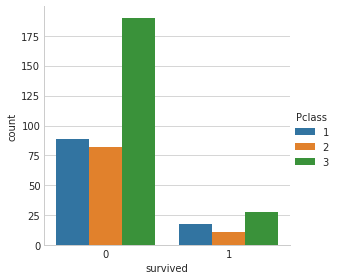

```python
sns.factorplot('survived',data=check_model,kind='count',hue='Pclass')
```

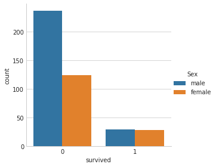

```python
sns.factorplot('survived',data=check_model,kind='count',hue='Sex')
```